# Approximating the Posterior

## Introduction

- We have learned how to think like a Bayesian:
  - Prior distribution
  - Data distribution
  - Posterior distribution
- We have learned three conjugate families:
  - Beta-Binomial (binary outcomes)
  - Gamma-Poisson (count outcomes)
  - Normal-Normal (continuous outcomes)
- Once we have a posterior model, we must be able to apply the results.
  - Posterior estimation
  - Hypothesis testing
  - Prediction

## Introduction

- Recall, we have the posterior pdf,

$$f(\theta|y) = \frac{f(\theta) L(\theta|y)}{f(y)} \propto f(\theta)L(\theta|y)$$

- Now, in the denominator, we need to remember,

$$f(y) = \int_{\theta_1} \int_{\theta_2} \cdot \cdot \cdot \int_{\theta_k} f(\theta) L(\theta|y) d\theta_k \cdot \cdot \cdot d\theta_2 d\theta_1$$

- Because this is … not fun … we will approximate the posterior via simulation.

## Introduction

- We are going to explore two simulation techniques:
  - grid approximation
  - Markov chain Monte Carlo (MCMC)
- Either method will produce a **sample** of $N$ values for $\theta$.

$$\left \{ \theta^{(1)}, \theta^{(2)}, ..., \theta^{(N)} \right \}$$

- These $\theta_i$ will have properties that reflect those of the posterior model for $\theta$.
- To help us, we will apply these simulation techniques to Beta-Binomial and Gamma-Poisson models.
  - Note that these models do not require simulation! We know their posteriors!
  - That’s why we are starting there – we can link the concepts to what we know. :)

## Introduction

- Note: we will use the following packages that may be new to you:
  - `janitor`
  - `rstan`
  - `bayesplot`
- If you are using the server provided by HMCSE, *they have been installed for you*.
- If you are working at home, please check to see if you have the libraries, then install if you do not.
  - `install.packages(c("janitor", "rstan", "bayesplot"))`

## Grid Approximation

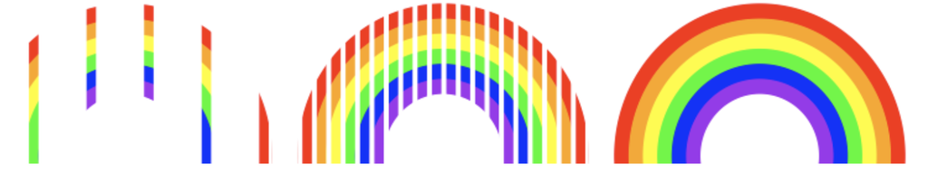

- Suppose there is an image that you can’t view in its entirety.
- We can see snippets along a grid that sweeps from left to right across the image.
- The finer the grid, the clearer the image; if the grid is fine enough, the result is a good approximation.

## Grid Approximation

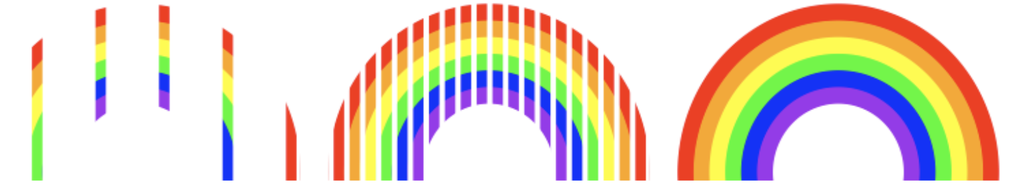

- This is the general idea behind Bayesian grid approximation.
- Our target image is the posterior pdf, $f(\theta|y)$.
  - It is not necessary to observe all possible $f(\theta|y) \ \forall \theta$ for us to understand its structure.
  - Instead, we evaluate $f(\theta|y)$ at a finite, discrete grid of possible $\theta$ values.
  - Then, we take random samples from this discretized pdf to approximate the full posterior pdf.

## Grid Approximation

- Grid approximation produces a sample of $N$ independent $\theta$ values,

$$\left\{ \theta^{(1)}, \theta^{(2)}, ..., \theta^{(N)} \right\},$$

from a discretized approximation of the posterior pdf, $f(\theta|y)$.

## Grid Approximation

- **Algorithm:**
  1. Define a discrete grid of possible $\theta$ values.
  2. Evaluate the prior pdf, $f(\theta)$, and the likelihood function, $L(\theta|y)$ at each $\theta$ grid value.
  3. Obtain a discrete approximation of the posterior pdf, $f(\theta|y)$ by:
     1. Calculating the product $f(\theta) L(\theta|y)$ at each $\theta$ grid value,
     2. Normalize the products from (a) to sum to 1 across all $\theta$.
  4. Randomly sample $N$ $\theta$ grid values with respect to their corresponding normalized posterior probabilities.

## Grid Approximation - Example

- We will use the following Beta-Binomial model to learn how to do grid approximation:

$$\begin{align*}
Y|\pi &\sim \text{Bin}(10, \pi) \\
\pi &\sim \text{Beta}(2, 2)
\end{align*}$$

- Note that
  - $Y$ is the number of successes in 10 independent trials.
  - Every trial has probability of success, $\pi$.
  - Our prior understanding about $\pi$ is captured by a $\text{Beta}(2,2)$ model.

## Grid Approximation - Example

- If we observe $Y = 9$ successes, we know that the updated posterior model for $\pi$ is $\text{Beta}(11, 3)$.
  - $Y + \alpha = 9+2$
  - $n - Y + \beta = 10-9+2$
- Thus,

$$\begin{align*}
Y|\pi &\sim \text{Bin}(10, \pi) \\
\pi &\sim \text{Beta}(2, 2) \\
\pi | Y &\sim \text{Beta}(11, 3)
\end{align*}$$

## Grid Approximation

- Instead of using the posterior we know, let’s approximate it using grid approximation.
- **First step:** define a discrete grid of possible $\theta$ values.
  - So, let’s consider $\pi \in \{0, 0.2, 0.4, 0.6, 0.8, 1\}$.

```r
library(tidyverse)
grid_data <- tibble(pi_grid = seq(from = 0, to = 1, length = 6))
```

## Grid Approximation

- Instead of using the posterior we know, let’s approximate it using grid approximation.
- **First step:** define a discrete grid of possible $\theta$ values.
  - So, let’s consider $\pi \in \{0, 0.2, 0.4, 0.6, 0.8, 1\}$.

```r
library(tidyverse)
grid_data <- tibble(pi_grid = seq(from = 0, to = 1, length = 6))
```

| pi_grid |
| --- |
| 0.0 |
| 0.2 |
| 0.4 |

## Grid Approximation

- Instead of using the posterior we know, let’s approximate it using grid approximation.
- **Second step:** evaluate the prior pdf, $f(\theta)$, and the likelihood function, $L(\theta|y)$ at each $\theta$ grid value.
  - We will use `dbeta()` and `dbinom()` to evaluate the $\text{Beta}(2,2)$ prior and $\text{Bin}(10, \pi)$ likelihood with $Y=9$ at each $\pi$ in `pi_grid`.

```r
grid_data <- grid_data %>%
  mutate(prior = dbeta(pi_grid, 2, 2),
         likelihood = dbinom(9, 10, pi_grid))
```

## Grid Approximation

- Instead of using the posterior we know, let’s approximate it using grid approximation.
- **Second step:** evaluate the prior pdf, $f(\theta)$, and the likelihood function, $L(\theta|y)$ at each $\theta$ grid value.
  - We will use `dbeta()` and `dbinom()` to evaluate the $\text{Beta}(2,2)$ prior and $\text{Bin}(10, \pi)$ likelihood with $Y=9$ at each $\pi$ in `pi_grid`.

```r
grid_data <- grid_data %>%
  mutate(prior = dbeta(pi_grid, 2, 2),
         likelihood = dbinom(9, 10, pi_grid))
```

| pi_grid | prior | likelihood |
| --- | --- | --- |
| 0.0 | 0.00 | 0.0000000 |
| 0.2 | 0.96 | 0.0000041 |
| 0.4 | 1.44 | 0.0015729 |

## Grid Approximation

- Instead of using the posterior we know, let’s approximate it using grid approximation.
- **Third step:** obtain a discrete approximation of the posterior pdf, $f(\theta|y)$ by calculating the product $f(\theta) L(\theta|y)$ at each $\theta$ grid value and normalizing the products to sum to 1 across all $\theta$.

```r
grid_data <- grid_data %>%
  mutate(unnormalized = likelihood*prior,
         posterior = unnormalized / sum(unnormalized))
```

## Grid Approximation

- Instead of using the posterior we know, let’s approximate it using grid approximation.
- **Third step:** obtain a discrete approximation of the posterior pdf, $f(\theta|y)$ by calculating the product $f(\theta) L(\theta|y)$ at each $\theta$ grid value and normalizing the products to sum to 1 across all $\theta$.

```r
grid_data <- grid_data %>%
  mutate(unnormalized = likelihood*prior,
         posterior = unnormalized / sum(unnormalized))
```

- We can verify,

```r
grid_data %>%
  summarize(sum(unnormalized), sum(posterior))
```

| sum(unnormalized) | sum(posterior) |
| --- | --- |
| 0.3180144 | 1 |

## Grid Approximation

- Instead of using the posterior we know, let’s approximate it using grid approximation.
- **Third step:** obtain a discrete approximation of the posterior pdf, $f(\theta|y)$ by calculating the product $f(\theta) L(\theta|y)$ at each $\theta$ grid value and normalizing the products to sum to 1 across all $\theta$.

```r
grid_data <- grid_data %>%
  mutate(unnormalized = likelihood*prior,
         posterior = unnormalized / sum(unnormalized))
```

| pi_grid | prior | likelihood | unnormalized | posterior |
| --- | --- | --- | --- | --- |
| 0.0 | 0.00 | 0.0000000 | 0.0000000 | 0.0000000 |
| 0.2 | 0.96 | 0.0000041 | 0.0000039 | 0.0000124 |
| 0.4 | 1.44 | 0.0015729 | 0.0022649 | 0.0071221 |

## Grid Approximation

- Instead of using the posterior we know, let’s approximate it using grid approximation.
- We now have a *glimpse* into the actual posterior pdf.
  - We can plot it to see what it looks like,

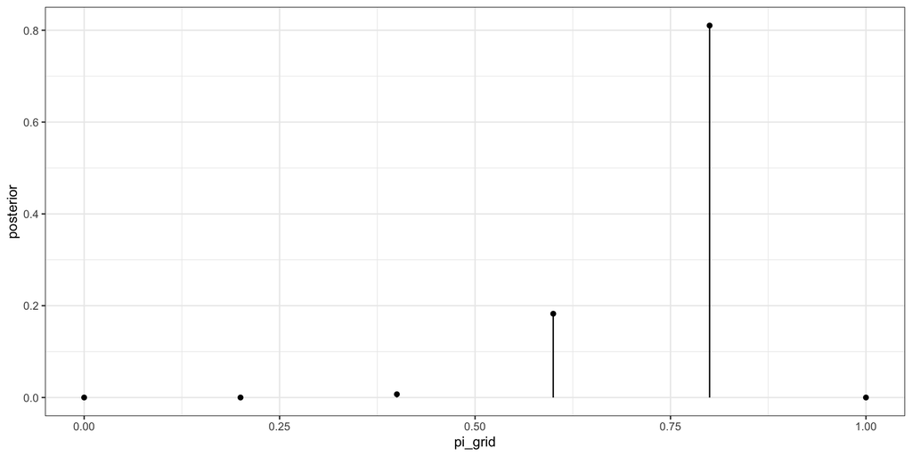

## Grid Approximation

- As we increase the number of possible $\theta$ values, the better we can “see” the resulting posterior.
- What happens if we try the following: $n=50$, $n=100$, $n=500$, $n=1000$?

## Grid Approximation

- As we increase the number of possible $\theta$ values, the better we can “see” the resulting posterior.
- What happens if we try the following: $n=50$, $n=100$, $n=500$, $n=1000$?

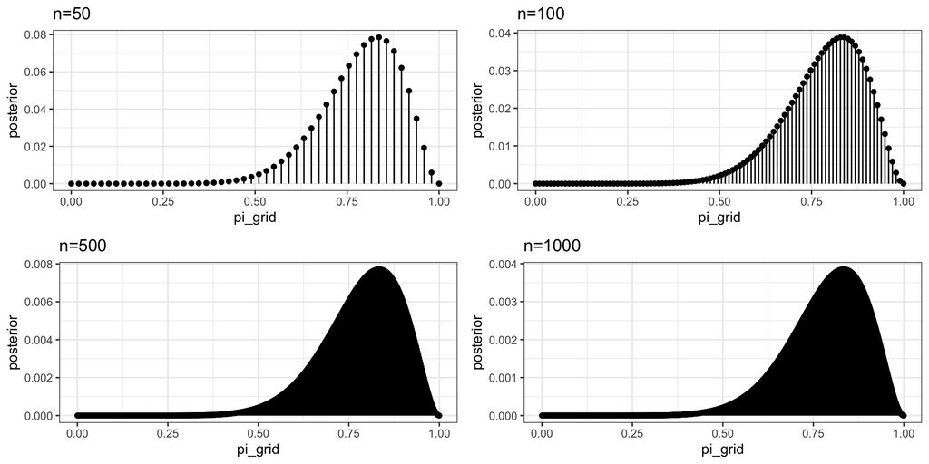

## Markov chain Monte Carlo (MCMC)

- Markov chain Monte Carlo (MCMC) is an application of [Markov chains](https://en.wikipedia.org/wiki/Markov_chain) to simulate probability models.
- MCMC samples are not taken directly from the posterior pdf, $f(\theta | y)$… and they are not independent.
  - Each subsequent value depends on the previous value.
- Suppose we have an $N$-length MCMC sample,
  $$\left\{ \theta^{(1)}, \theta^{(2)}, \theta^{(3)}, ..., \theta^{(N)} \right\}$$
  - $\theta^{(2)}$ is drawn from a model that depends on $\theta^{(1)}$.
  - $\theta^{(3)}$ is drawn from a model that depends on $\theta^{(2)}$.
  - etc.

## Markov chain Monte Carlo (MCMC)

- The $(i+1)$<sup>st</sup> chain value, $\theta^{(i+1)}$ is drawn from a model that depends on data $y$ and the previous chain value, $\theta^{(i)}$.

$$f\left( \theta^{(i+1)} | \theta^{(i)}, y \right)$$

- It is important for us to note that the pdf from which a Markov chain is simulated is not equivalent to the posterior pdf!

$$f\left( \theta^{(i+1)} | \theta^{(i)}, y \right) \ne f\left(\theta^{(i+1)}|y \right)$$

## Using `rstan`

- We will use `rstan`:
  - define the Bayesian model structure in `rstan` notation
  - simulate the posterior
- Again, we will use the Beta-Binomial model from earlier.
  - `data`: in our example, $Y$ is the observed number of successes in 10 trials.
    - We need to tell `rstan` that $Y$ is an *integer* between 0 and 10.
  - `parameters`: in our example, our model depends on $\pi$.
    - We need to tell `rstan` that $\pi$ can be any *real* number between 0 and 1.
  - `model`: in our example, we need to specify $Y \sim \text{Bin}(10, \pi)$ and $\pi \sim \text{Beta}(2,2)$.

## Using `rstan`

```r
# STEP 1: DEFINE the model
bb_model <- "
  data {
    int<lower = 0, upper = 10> Y;
  }
  parameters {
    real<lower = 0, upper = 1> pi;
  }
  model {
    Y ~ binomial(10, pi);
    pi ~ beta(2, 2);
  }
"
```

## Using `rstan`

- Then, when we go to simulate, we first put in the model information
  - `model code`: the character string defining the model (in our case, `bb_model`).
  - `data`: a list of the observed data.
    - In this example, we are using $Y = 9$ - a single data point.
- Then, we put in the Markov chain information,
  - `chains`: how many parallel Markov chains to run.
    - This will be the number of distinct $\theta$ values we want.
  - `iter`: desired number of iterations, or length of Markov chain.
    - Half are thrown out as “burn in” samples.
      - “burn in”? Think: pancakes!
  - `seed`: used to set the seed of the RNG.

## Using `rstan`

```r
# STEP 2: simulate the posterior
bb_sim <- stan(model_code = bb_model, data = list(Y = 9),
               chains = 4, iter = 5000*2, seed = 84735)
```

## Using `rstan`

- Now, we need to extract the values,

```r
as.array(bb_sim, pars = "pi") %>% head(4)
```

```
, , parameters = pi

          chains
iterations   chain:1   chain:2   chain:3   chain:4
      [1,] 0.8278040 0.7523560 0.6386998 0.9627572
      [2,] 0.9087546 0.8922386 0.6254761 0.9413518
      [3,] 0.6143859 0.8682356 0.7222360 0.9489624
      [4,] 0.8462156 0.8792812 0.8100192 0.9413812
```

- Remember, these are *not* a random sample from the posterior!
- They are also *not* independent!
- Each chain forms a dependent 5,000 length Markov chain of $\left\{ \pi^{(1)}, \pi^{(2)}, ..., \pi^{(5000)}\right\}$
  - Each chain will move along the sample space of plausible values for $\pi$.

## Using `rstan`

- We will look at the trace plot (using `mcmc_trace()` from `bayesplot` package) to see what the values did longitudinally.

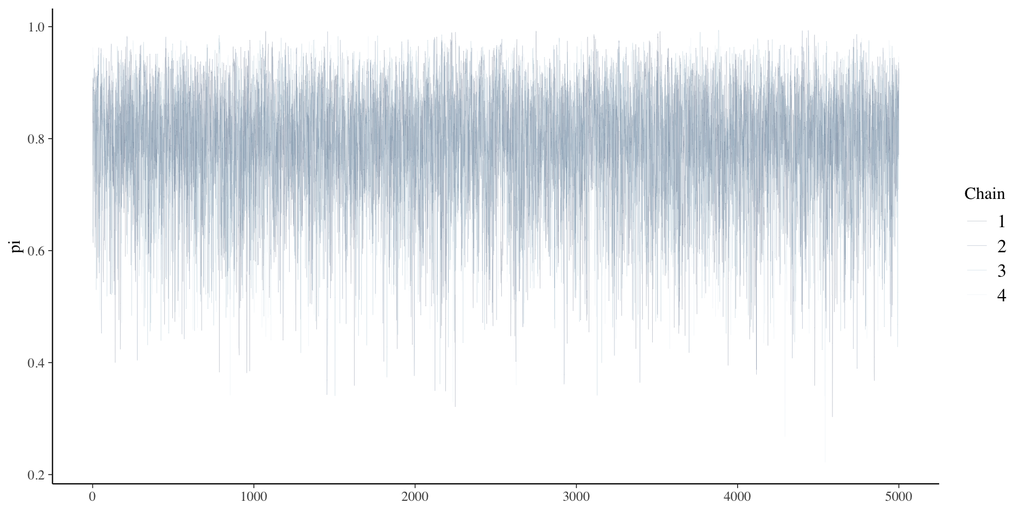

```r
mcmc_trace(bb_sim, pars = "pi", size = 0.1)
```

## Using `rstan`

- We can also look at the `mcmc_hist()` and `mcmc_dens()` functions,

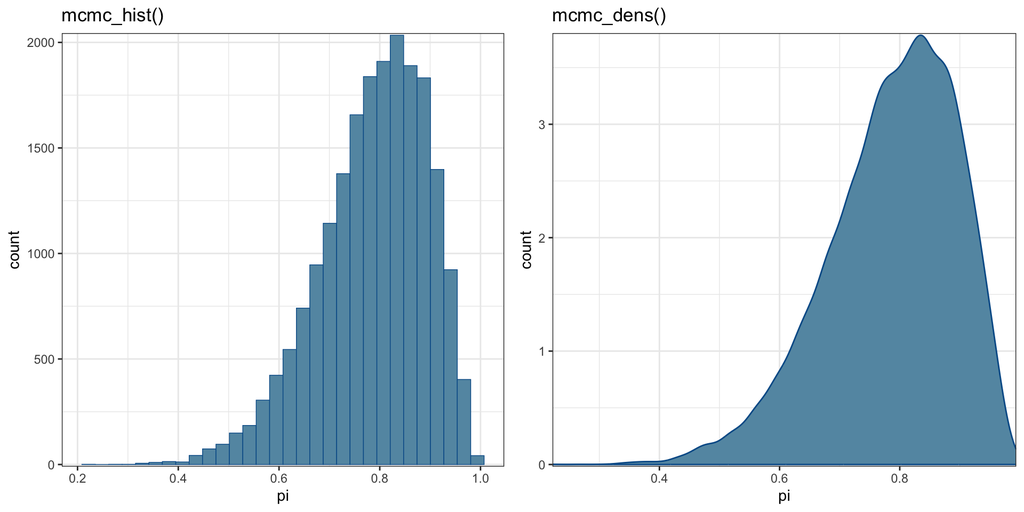

## Diagnostics

- Simulations are not perfect…
  - What does a good Markov chain look like?
  - How can we tell if the Markov chain sample produces a reasonable approximation of the posterior?
  - How big should our Markov chain sample size be?
- Unfortunately there is no one answer here.
  - You will learn through experience, much like other nuanced areas of statistics.

## Diagnostics

- Let’s now discuss diagnostic tools.
  - Trace plots
  - Parallel chains
  - Effective sample size
  - Autocorrelation
  - $\hat{R}$

## Trace Plots

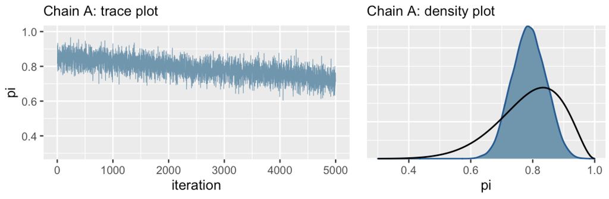

- Chain A has not stabilized after 5000 iterations.
  - It has not “found” or does not know how to explore the range of posterior plausible $\pi$ values.
  - The downward trend also hints against independent noise.

## Trace Plots

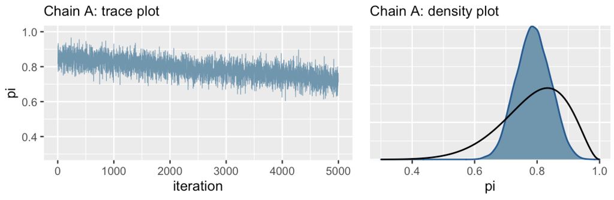

- We say that Chain A is mixing slowly.
  - The more Markov chains behave like fast mixing (noisy) independent samples, the smaller the error in the resulting posterior approximation.

## Trace Plots

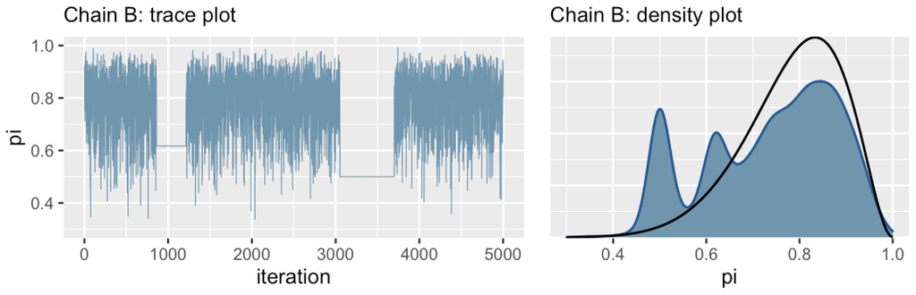

- Chain B is not great, either – it gets stuck when looking at a smaller value of $\pi$.

## Trace Plots

- Realistically, we are only going to do simulations when we can’t specify the posterior and must approximate
  - i.e., we won’t be able to compare the simulation results to the “true” results.
- If we see bad trace plots:
  - Check the model (… or your code). Are the assumed prior and data models appropriate?
  - Run the chain for more iterations. Sometimes we just need a longer run to iron out issues.

## Parallel Chains

- Let’s now consider a smaller simulation, where $n=50$ (recall, overall $n=100$, but half is for burn-in).
- Run the following code:

```r
bb_sim_short <- stan(model_code = bb_model, data = list(Y = 9),
                     chains = 4, iter = 50*2, seed = 84735)
```

## Parallel Chains

- Let’s now consider a smaller simulation, where $n=50$ (recall, overall $n=100$, but half is for burn-in).
- Run the following code:

```r
bb_sim_short <- stan(model_code = bb_model, data = list(Y = 9),
                     chains = 4, iter = 50*2, seed = 84735)
```

## Parallel Chains

- Let’s now generate the trace and density plots for the smaller simulation:

```r
ggarrange(mcmc_trace(bb_sim_short, pars = "pi") + ggtitle("trace") + theme_bw() + theme(legend.position="none"),
          mcmc_dens_overlay(bb_sim_short, pars = "pi") + ylab("density") + ggtitle("density") + theme_bw(),
          ncol=2, nrow=1)
```

[output not shown]